# City Genre

*Jintong Yu, Xianfeng Jiang*

In the travel industry, recommendation systems have become increasingly important in enhancing user experience and driving sales and services. Specifically, online travel platforms use recommendation systems based on the concept of destination similarity.

To identify patterns in the attributes of 180 popular travel destinations suggested by Priceline.com, we collected data related to the destinations’ attributes from various online sources. Our aim is to use this data to identify inherent patterns in the attributes and apply clustering, a machine learning technique, to explore destination similarity.

## Interactive World Map

The interactive world map showcases the 180 target travel destinations and provides longitude and latitude coordinates for each destination. Using the “Stamen.TonerLite” base map, we can easily identify geographical features, such as whether a destination is inland or seaside, and its corresponding cluster. Users can zoom in on the map to explore members within each geographical cluster.

[interactive chart not shown]

## Three Key Patterns

Our analysis focused on three key features: number of visitors in 2019, temperature, and climate types for a comprehensive understanding of a travel destination. Examining visitor numbers provided insight into popularity and the potential for off-the-beaten-path destinations. Temperature and climate type impact a traveler’s experience, with some preferring cooler temperatures or specific climates that influence outdoor activities or cultural experiences. These features can aid in better understanding a destination and enhancing a traveler’s experience.

### Number of Visitors in 2019

The bar chart displays the top 10 travel destinations based on 2019 visitor numbers, providing insight into popular destinations worldwide. It’s useful for travelers seeking inspiration and for businesses in the tourism industry to make informed decisions, such as where to invest resources or prioritize marketing campaigns. The chart also highlights emerging travel trends, identifying new popular destinations or declines in visitor numbers for previously popular destinations.

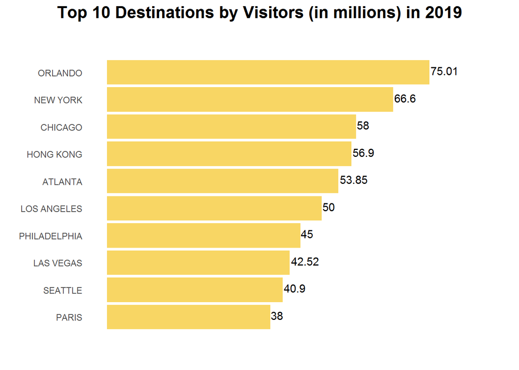

### Temperature

The density plot compares average temperatures between December to February and June to August, with the area under the curve representing the proportion of destinations in specific temperature ranges. It highlights common temperature ranges for each period, valuable information for travelers planning their trips. The graph indicates warm destinations for winter vacations and pleasant temperatures for summer travel, aiding travelers in making informed decisions. Businesses can use this information to tailor marketing strategies and services to meet customers’ needs.

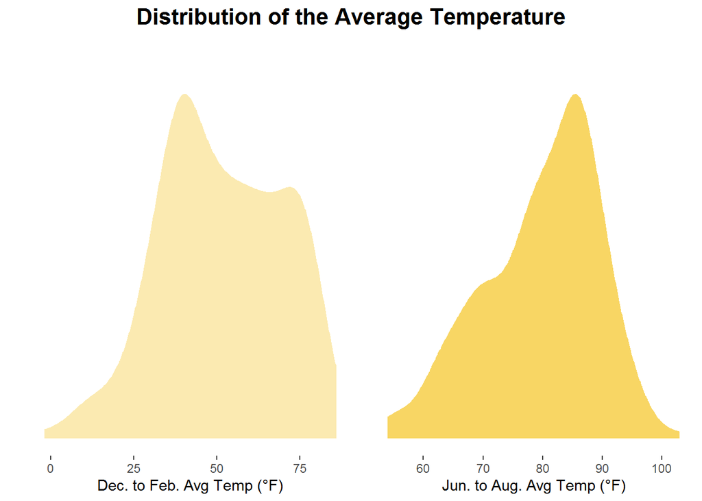

### Climate Types

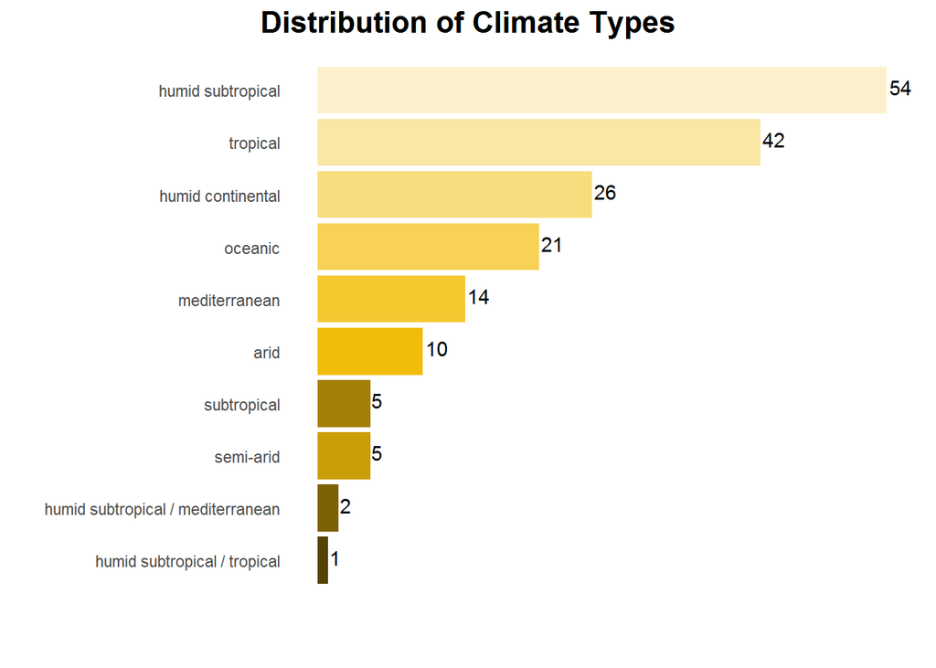

## City Clusters

We began by conducting an exploratory analysis of the three key features, following which we utilized a hierarchical clustering algorithm to identify potential groups among the target travel destinations. The resulting dendrogram displayed the degree of distinction between clusters, and based on the length of branches, we divided the destinations into six clusters, labeling each with its corresponding cluster.

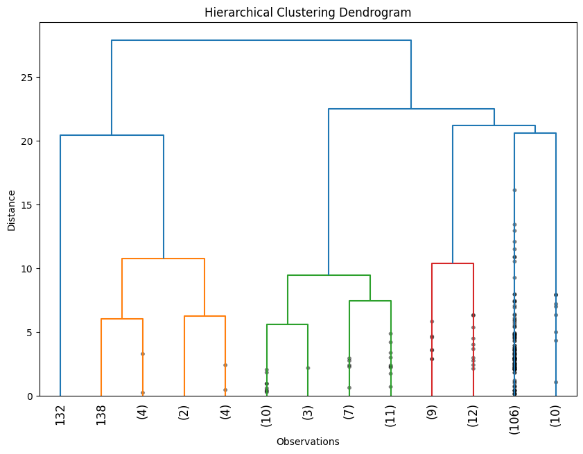

To further understand the characteristics of each cluster, we analyzed the mean values of all features. Based on this analysis, we defined the genres of each cluster as follows:

- Outdoor Adventure Destinations
- Water-based Cultural Tourism Destinations
- Cold Climate Outdoor Activity Destinations
- Mountainous Outdoor Adventure Destinations
- Leisurely Coastal/Tropical Outdoor Activity Destinations
- Summer Water Activity Destinations

## Patterns within Clusters

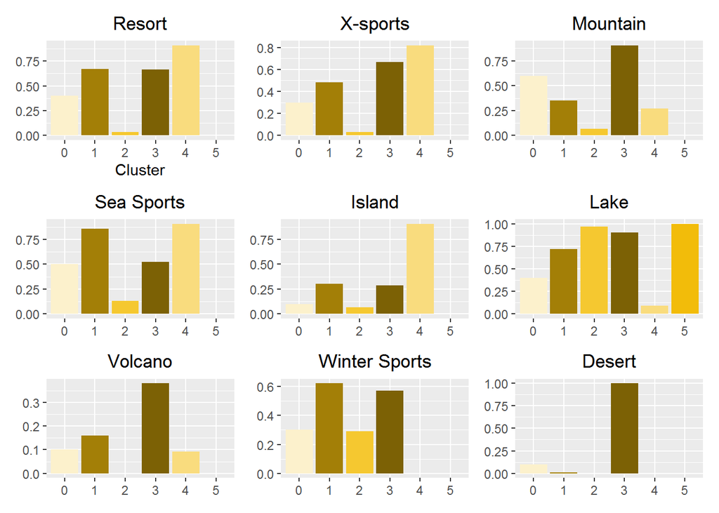

## Text Analysis

We collected text data for our dataset from reliable sources like TripAdvisor and Wikipedia. To ensure complete coverage, we extracted all paragraphs from each Wikipedia page as their layout varies. For TripAdvisor, we scraped only the text about each destination’s attractions.

### Interactive Word Cloud

This interactive Word Cloud displays the most frequently used words to describe travel destinations extracted from TripAdvisor webpages. Each word’s size corresponds to its frequency of occurrence in the text. The word “museum” stands out as the most frequently used word in the text, indicating that the majority of the 180 travel destinations have museum-related attractions. Other notable words include “beach,” “mountain,” “city,” and “historic,” suggesting that these features are highly associated with popular travel destinations.

[interactive chart not shown]

### Common Words within Clusters

The wrapped-up bar charts provide insights into the most frequently used words in each cluster of travel destinations. The first four clusters show that “museum” is the most common word, indicating that these destinations are known for their cultural and historical attractions. . The remaining two clusters have “beach” and “park” as their top words, respectively, implying that these destinations are associated with natural attractions such as beaches and parks, and outdoor activities.

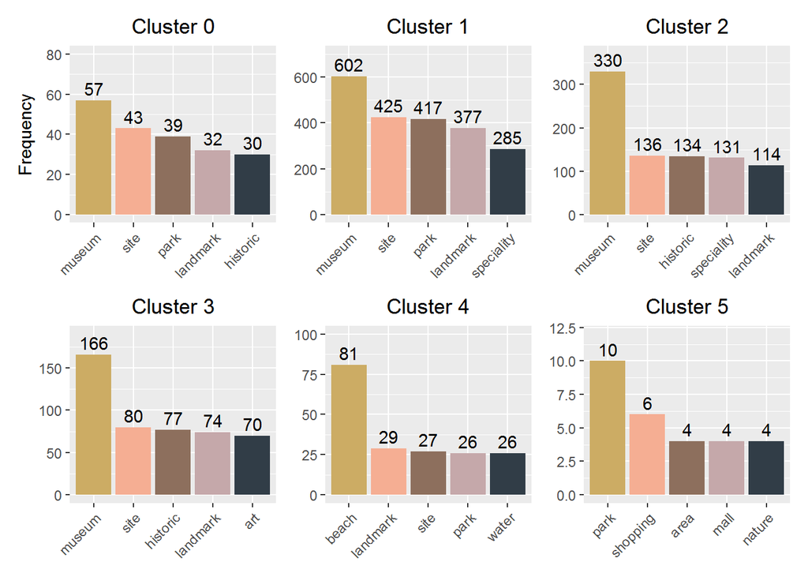

## Conclusions

In conclusion, this study aimed to identify patterns in the attributes of 180 popular travel destinations suggested by Priceline.com, by collecting data from various online sources and trusted websites. Through an exploratory data analysis, we identified key features of the destinations, such as outdoor activities, cultural tourism, and cold climate activities. We then applied clustering, a machine learning technique, to identify potential groups within the destinations. The results revealed six distinct clusters, each with unique features and travel genres. This approach has the potential to improve the recommendation systems of online travel platforms by providing a more personalized and relevant experience for users. Overall, this study contributes to the understanding of travel destination attributes and has practical implications for the travel industry.